# Salifort Motors Employee Retention Predictor

### Business scenario and problem

The HR department at Salifort Motors wants to take some initiatives to improve employee satisfaction levels at the company. They collected data from employees, but now they don’t know what to do with it. They refer to you as a data analytics professional and ask you to provide data-driven suggestions based on your understanding of the data. They have the following question: what’s likely to make the employee leave the company?

Your goals in this project are to analyze the data collected by the HR department and to build a model that predicts whether or not an employee will leave the company.

If you can predict employees likely to quit, it might be possible to identify factors that contribute to their leaving. Because it is time-consuming and expensive to find, interview, and hire new employees, increasing employee retention will be beneficial to the company.

## HR Dataset

The dataset contains 15,000 rows and 10 columns for the variables listed below.

Source on [Kaggle](https://www.kaggle.com/datasets/mfaisalqureshi/hr-analytics-and-job-prediction?select=HR_comma_sep.csv).

| Variable | Description |  |
| --- | --- | --- |
| satisfaction_level | Employee-reported job satisfaction level [0–1] |  |
| last_evaluation | Score of employee's last performance review [0–1] |  |
| number_project | Number of projects employee contributes to |  |
| average_monthly_hours | Average number of hours employee worked per month |  |
| time_spend_company | How long the employee has been with the company (years) |  |
| Work_accident | Whether or not the employee experienced an accident while at work |  |
| left | Whether or not the employee left the company |  |
| promotion_last_5years | Whether or not the employee was promoted in the last 5 years |  |
| Department | The employee's department |  |
| salary | The employee's salary (U.S. dollars) |  |

### Import packages

```python
# Import packages
import pandas as pd
import numpy as np

import matplotlib.pyplot as plt
import seaborn as sns

from sklearn.model_selection import train_test_split


from xgboost import XGBClassifier, plot_importance


from sklearn.preprocessing import LabelEncoder


from sklearn.model_selection import KFold,  cross_val_score # for validation of the model

from sklearn.metrics import classification_report, accuracy_score, precision_score, \
recall_score, f1_score, confusion_matrix, ConfusionMatrixDisplay
```

### Load dataset

```python
df0 = pd.read_csv("HR_capstone_dataset.csv")
df0.sample(5)
```

|  | satisfaction_level | last_evaluation | number_project | average_montly_hours | time_spend_company | Work_accident | left | promotion_last_5years | Department | salary |
| --- | --- | --- | --- | --- | --- | --- | --- | --- | --- | --- |
| 11879 | 0.78 | 0.80 | 3 | 256 | 2 | 0 | 0 | 0 | IT | medium |
| 10740 | 0.97 | 0.83 | 3 | 238 | 2 | 0 | 0 | 0 | support | medium |
| 6655 | 0.95 | 0.49 | 4 | 178 | 2 | 0 | 0 | 0 | sales | low |
| 12347 | 0.11 | 0.80 | 6 | 282 | 4 | 0 | 1 | 0 | technical | medium |
| 2926 | 0.82 | 0.84 | 3 | 139 | 2 | 1 | 0 | 0 | sales | low |

## Data Exploration (Initial EDA and data cleaning)

### Gather basic information about the data

Data Dictionary

satisfaction_level - int64 - The employee’s self-reported satisfaction level [0-1]

last_evaluation - int64 - Score of employee's last performance review [0–1]

number_project - int64 - Number of projects employee contributes to

average_monthly_hours - int64 - Average number of hours employee worked per month

time_spend_company - int64 - How long the employee has been with the company (years)

work_accident - int64 - Whether or not the employee experienced an accident while at work

left - int64 - Whether or not the employee left the company

promotion_last_5years - int64 - Whether or not the employee was promoted in the last 5 years

department - str - The employee's department

salary - str - The employee's salary (low, medium, or high)

```python
# Gather basic information about the data
df0.info()
```

```
<class 'pandas.core.frame.DataFrame'>
RangeIndex: 14999 entries, 0 to 14998
Data columns (total 10 columns):
 #   Column                 Non-Null Count  Dtype
---  ------                 --------------  -----
 0   satisfaction_level     14999 non-null  float64
 1   last_evaluation        14999 non-null  float64
 2   number_project         14999 non-null  int64
 3   average_montly_hours   14999 non-null  int64
 4   time_spend_company     14999 non-null  int64
 5   Work_accident          14999 non-null  int64
 6   left                   14999 non-null  int64
 7   promotion_last_5years  14999 non-null  int64
 8   Department             14999 non-null  object
 9   salary                 14999 non-null  object
dtypes: float64(2), int64(6), object(2)
memory usage: 1.1+ MB
```

```python
df0.columns
```

```
Index(['satisfaction_level', 'last_evaluation', 'number_project',
       'average_montly_hours', 'time_spend_company', 'Work_accident', 'left',
       'promotion_last_5years', 'Department', 'salary'],
      dtype='object')
```

No null values, which makes things easy.

Based on the Data dictionary we have

ordinal categorical: 'salary'(need to encode)

discrete: 'number_project', 'average_montly_hours' ,'time_spend_company'

continous: 'satisfaction_level' (0-1), 'last_evaluation' (0-1)

binary: 'promotion_last_5years','Work_accident', 'left'(target)

categorical: 'Department'

### Gather descriptive statistics about the data

```python
# Gather descriptive statistics about the data
df0.describe()
```

|  | satisfaction_level | last_evaluation | number_project | average_montly_hours | time_spend_company | Work_accident | left | promotion_last_5years |
| --- | --- | --- | --- | --- | --- | --- | --- | --- |
| count | 14999.000000 | 14999.000000 | 14999.000000 | 14999.000000 | 14999.000000 | 14999.000000 | 14999.000000 | 14999.000000 |
| mean | 0.612834 | 0.716102 | 3.803054 | 201.050337 | 3.498233 | 0.144610 | 0.238083 | 0.021268 |
| std | 0.248631 | 0.171169 | 1.232592 | 49.943099 | 1.460136 | 0.351719 | 0.425924 | 0.144281 |
| min | 0.090000 | 0.360000 | 2.000000 | 96.000000 | 2.000000 | 0.000000 | 0.000000 | 0.000000 |
| 25% | 0.440000 | 0.560000 | 3.000000 | 156.000000 | 3.000000 | 0.000000 | 0.000000 | 0.000000 |
| 50% | 0.640000 | 0.720000 | 4.000000 | 200.000000 | 3.000000 | 0.000000 | 0.000000 | 0.000000 |
| 75% | 0.820000 | 0.870000 | 5.000000 | 245.000000 | 4.000000 | 0.000000 | 0.000000 | 0.000000 |
| max | 1.000000 | 1.000000 | 7.000000 | 310.000000 | 10.000000 | 1.000000 | 1.000000 | 1.000000 |

### Rename columns

As a data cleaning step, rename the columns as needed. Standardize the column names so that they are all in `snake_case`, correct any column names that are misspelled, and make column names more concise as needed.

```python
# Display all column names
df0.columns
```

```
Index(['satisfaction_level', 'last_evaluation', 'number_project',
       'average_montly_hours', 'time_spend_company', 'Work_accident', 'left',
       'promotion_last_5years', 'Department', 'salary'],
      dtype='object')
```

```python
# Rename columns as needed
col_renames = {'number_project':'number_of_projects',
       'average_montly_hours':'average_monthly_hours',
        'time_spend_company':'years_at_company',
        'Work_accident':'work_accident',
       'Department':'department'}
df0.rename(columns=col_renames, inplace=True)
# Display all column names after the update
df0.columns
```

```
Index(['satisfaction_level', 'last_evaluation', 'number_of_projects',
       'average_monthly_hours', 'years_at_company', 'work_accident', 'left',
       'promotion_last_5years', 'department', 'salary'],
      dtype='object')
```

### Check missing values

Check for any missing values in the data.

```python
# Check for missing values
df0.isnull().sum()
```

```
satisfaction_level       0
last_evaluation          0
number_of_projects       0
average_monthly_hours    0
years_at_company         0
work_accident            0
left                     0
promotion_last_5years    0
department               0
salary                   0
dtype: int64
```

### Check duplicates

Check for any duplicate entries in the data.

```python
# Check for duplicates
df0.duplicated().sum()
```

```
3008
```

```python
# Inspect some rows containing duplicates as needed
df0[df0.duplicated()]
```

|  | satisfaction_level | last_evaluation | number_of_projects | average_monthly_hours | years_at_company | work_accident | left | promotion_last_5years | department | salary |
| --- | --- | --- | --- | --- | --- | --- | --- | --- | --- | --- |
| 396 | 0.46 | 0.57 | 2 | 139 | 3 | 0 | 1 | 0 | sales | low |
| 866 | 0.41 | 0.46 | 2 | 128 | 3 | 0 | 1 | 0 | accounting | low |
| 1317 | 0.37 | 0.51 | 2 | 127 | 3 | 0 | 1 | 0 | sales | medium |
| 1368 | 0.41 | 0.52 | 2 | 132 | 3 | 0 | 1 | 0 | RandD | low |
| 1461 | 0.42 | 0.53 | 2 | 142 | 3 | 0 | 1 | 0 | sales | low |
| ... | ... | ... | ... | ... | ... | ... | ... | ... | ... | ... |
| 14994 | 0.40 | 0.57 | 2 | 151 | 3 | 0 | 1 | 0 | support | low |
| 14995 | 0.37 | 0.48 | 2 | 160 | 3 | 0 | 1 | 0 | support | low |
| 14996 | 0.37 | 0.53 | 2 | 143 | 3 | 0 | 1 | 0 | support | low |
| 14997 | 0.11 | 0.96 | 6 | 280 | 4 | 0 | 1 | 0 | support | low |
| 14998 | 0.37 | 0.52 | 2 | 158 | 3 | 0 | 1 | 0 | support | low |

3008 rows × 10 columns

```python
# Drop duplicates and save resulting dataframe in a new variable as needed
df1=df0[~df0.duplicated()]


# Display first few rows of new dataframe as needed
df1.sample(5)
```

|  | satisfaction_level | last_evaluation | number_of_projects | average_monthly_hours | years_at_company | work_accident | left | promotion_last_5years | department | salary |
| --- | --- | --- | --- | --- | --- | --- | --- | --- | --- | --- |
| 11867 | 0.56 | 0.59 | 3 | 223 | 3 | 0 | 0 | 0 | support | medium |
| 4789 | 0.97 | 0.91 | 4 | 257 | 3 | 1 | 0 | 0 | technical | low |
| 9548 | 0.61 | 0.37 | 4 | 165 | 6 | 0 | 0 | 0 | marketing | medium |
| 1006 | 0.40 | 0.47 | 2 | 151 | 3 | 0 | 1 | 0 | sales | medium |
| 1396 | 0.20 | 0.70 | 6 | 281 | 5 | 0 | 1 | 0 | sales | medium |

```python
# Check balance of dataset
print(df1['left'].value_counts(normalize=True))
```

```
0    0.833959
1    0.166041
Name: left, dtype: float64
```

Fairly unbalanced (84/16 retained/left), so will need to deal with that. may not be too much of an issue with XGBoost but some upsampling could be used.

```python
df1.columns
```

```
Index(['satisfaction_level', 'last_evaluation', 'number_of_projects',
       'average_monthly_hours', 'years_at_company', 'work_accident', 'left',
       'promotion_last_5years', 'department', 'salary'],
      dtype='object')
```

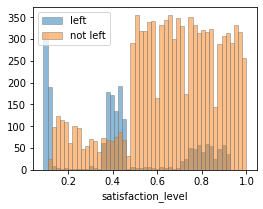

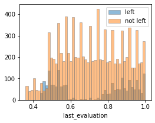

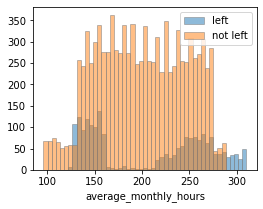

```python
#list of numerical columns
cont_cols = ['satisfaction_level', 'last_evaluation', 'average_monthly_hours']

target_var='left'


data=df1
for col in cont_cols:
    fig, ax = plt.subplots(1, 1, figsize=(4,3))


    bins = np.linspace(np.nanmin(data[col]), np.nanmax(data[col]), 50)
    ax.hist(data[data[target_var]==1][col], label=target_var, bins=bins, alpha=0.5, edgecolor='grey')
    ax.hist(data[data[target_var]==0][col], label='not '+target_var, bins=bins, alpha=0.5, edgecolor='grey')
    ax.legend()
    ax.set_xlabel(col)
```

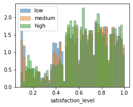

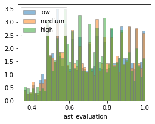

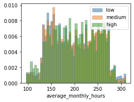

```python
#list of numerical columns
cont_cols = ['satisfaction_level', 'last_evaluation', 'average_monthly_hours']

check_var='salary'


data=df1
for col in cont_cols:
    fig, ax = plt.subplots(1, 1, figsize=(4,3))


    bins = np.linspace(np.nanmin(data[col]), np.nanmax(data[col]), 50)

    for label in data[check_var].unique():
        ax.hist(data[data[check_var]==label][col], label=label, bins=bins, alpha=0.5, edgecolor='grey', density=True)

    ax.legend()
    ax.set_xlabel(col)
```

Unsurprisingly, low satisfaction indicates the employee has left. Two clear groups that leave in terms of average monthly hours and evaluations. People working ~300 hours or more are very likely to leaveAlso satisfaction could be split into extremely unhappy, moderate satisfaction or happy

Looking at Salary, most these distributions are pretty similar. For satsfaction level there are a higher portion of unsatisfied contignent of low/medium earners than high.that

```
number_of_projects  left
2                   1       0.541719
                    0       0.458281
3                   0       0.989205
                    1       0.010795
4                   0       0.935685
                    1       0.064315
5                   0       0.846395
                    1       0.153605
6                   0       0.550847
                    1       0.449153
7                   1       1.000000
Name: left, dtype: float64
0.4582806573957016
0.9892045454545455
0.935685210312076
0.8463949843260188
0.5508474576271186
0.0
0.5417193426042983
0.010795454545454546
0.06431478968792402
0.1536050156739812
0.4491525423728814
1.0


years_at_company  left
2                 0       0.989347
                  1       0.010653
3                 0       0.831599
                  1       0.168401
4                 0       0.753117
                  1       0.246883
5                 0       0.546139
                  1       0.453861
6                 0       0.798893
                  1       0.201107
7                 0       1.000000
8                 0       1.000000
```

[output cut: 87 more lines]

```

salary  left
high    0       0.951515
        1       0.048485
low     0       0.795470
        1       0.204530
medium  0       0.853830
        1       0.146170
Name: left, dtype: float64
0.9515151515151515
0.7954703832752613
0.8538300703288348
0.048484848484848485
0.20452961672473868
0.14616992967116518
```

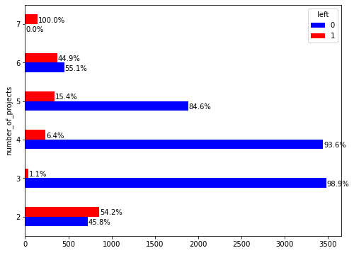

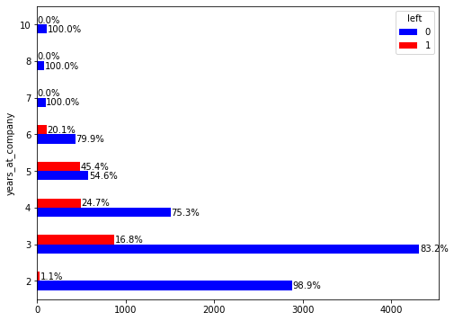

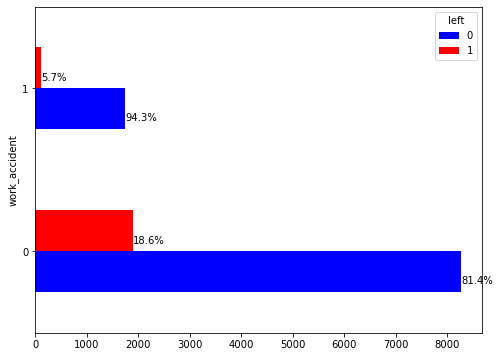

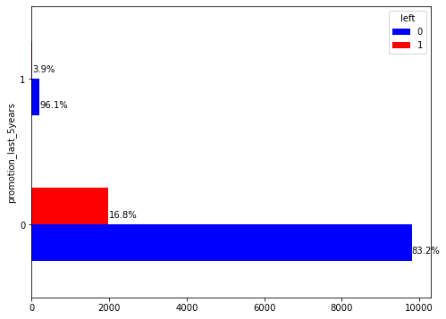

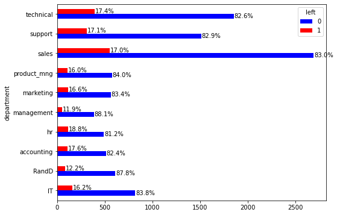

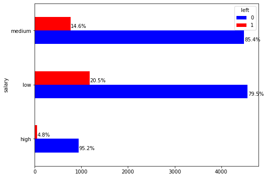

```python
#list of numerical columns
disc_cols = ['number_of_projects', 'years_at_company', 'work_accident',
       'promotion_last_5years', 'department', 'salary']

target_var='left'

annotate=True
data=df1
for col in disc_cols:
    fig, ax = plt.subplots(1, 1, figsize=(8,6))


    #gb = df1.groupby([target_var, col])[col].count().reset_index()

    gb = df1.groupby([col, target_var])[target_var]
    print(df1.groupby([col])[target_var].value_counts(normalize=True))
    gb.count().unstack().plot(kind='barh', legend=True, color=['b', 'r' ], ax=ax)
    for c, container in enumerate(ax.containers):

        for i, p in enumerate(container):
            group_total = ax.containers[0][i].get_width() + ax.containers[1][i].get_width()

            width = p.get_width()
            height = p.get_height()
            x, y = p.get_xy()

            print(width/group_total)

            if annotate:
                ax.annotate('{:.1f}%'.format(100*width/group_total), (x +width + 5, i + (c-1)*0.25  + 0.05), ha='left')

            #print(f'{(width)}')
    print('\n')
```

Some insights:

'number_of_projects' - 3 projects seems to be the sweet spot, too few and employees are likely to leave (may be thatthey are bad employees and that why they only have 2 projects, can check this). After 3-4 projects employee are increasing likely to leave.

'years_at_company' - year ~5 seems to be a critical point for whether an employee determines whether to stay or leave. Make it to past years and very likely to stay. Departures begin to deviate form typical at ~4 years.

'work_accident' - possible that theres a correlation between tenure and work accident whcih could explain why employees that have experienced a work accident stay ata higher rate.

'promotion_last_5years' - strong indicator of staying but very small sample size, those promoted in the last five years are unlikely to leave

'department' - mostly indepnednt, slightly higher fraction for management

'salary' - directly correlates with fraction that stay]

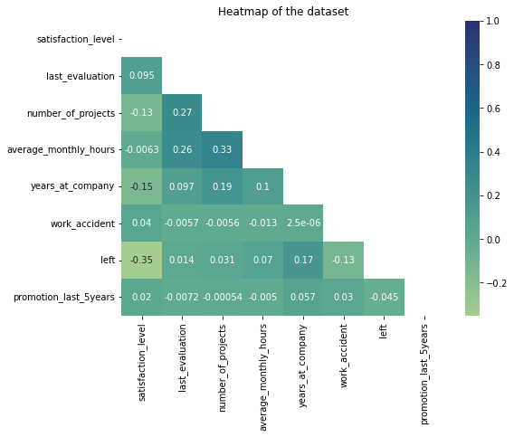

```python
corr = df1.corr()

trimask = np.triu(np.ones_like(corr, dtype=bool))

# Create a heatmap to visualize how correlated variables are
plt.figure(figsize=(8, 6))
sns.heatmap(corr,
    annot=True,
    cmap="crest", mask=trimask, vmax=1)
plt.title("Heatmap of the dataset")
plt.show()
```

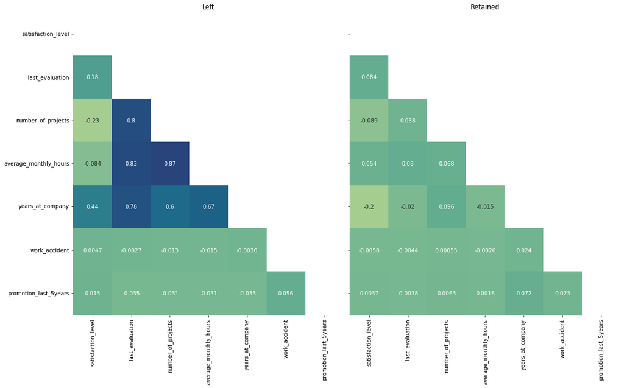

```python
corr1 = df1[df1['left']==1].drop(columns=['left']).corr()
corr2 = df1[df1['left']==0].drop(columns=['left']).corr()
trimask = np.triu(np.ones_like(corr1, dtype=bool))

# Create a heatmap to visualize how correlated variables are
fig, ax = plt.subplots(1,2, figsize=(16,10))
sns.heatmap(corr1,
    annot=True,
    cmap="crest", mask=trimask, vmax=1, ax=ax[0], cbar=False)
ax[0].set_title('Left')
sns.heatmap(corr2,
    annot=True,
    cmap="crest", mask=trimask, vmax=1, ax=ax[1], cbar=False)
ax[1].set_yticklabels([])
ax[1].set_title('Retained')
plt.tight_layout()
```

Here in the correlation we can see that for the employees that left, there arefairly strong correlations in the number of projects, avregae monthly hours, and last evaluation

## EDA ToDo

Somer ANOVA/ANCOVA could be interesting. We clearly some strong predictor features (e.g. number of projects, years). And surely these have some interplay. Other relations to explore more ind depth could be satisfaction, eval, number of project, eval by year etc.

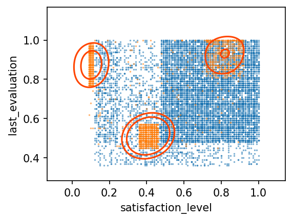

```python
df_aff = df1[df1[target_var]==1]
df_neg = df1[df1[target_var]==0]

xvar = 'satisfaction_level'
yvar = 'last_evaluation'

plt.figure(figsize=(4,3), dpi=150)

plt.scatter(df_neg[xvar], df_neg[yvar], alpha=0.5, s=0.5, label='0')
plt.scatter(df_aff[xvar], df_aff[yvar], alpha=0.5, s=0.5, label='1')

ax =plt.gca()

sns.kdeplot(data=df_aff, x=xvar, y=yvar,  fill=False , ax=ax, color='orangered',levels=[0.4, 0.65])

plt.xlabel(xvar)
plt.ylabel(yvar)
```

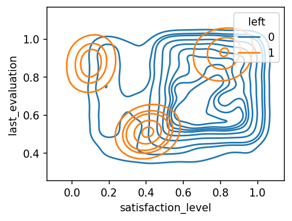

```python
plt.figure(figsize=(4,3), dpi=150)
sns.kdeplot(data=df1, x=xvar, y=yvar, hue='left', fill=False)
```

With these plots we see some very distinct patterns for employees that decide to leave. This is almost ceratinly an effect of the fact that we are using artificial data, but it demonstrates that we should be able to constuct a pretty effective classifier.

Also the fact that these groups essentially cover the full range of eval and satisfaction space could explain why a simple correlation test does not yield high correlation values

There are three distinct hotspots for employees to leave:

Low satisfaction - high evaluation (i.e. performance) Unhappy employees, presumably good enough to find work elsewhere.

high satisfaction - high evaluation (i.e. performance) These employees leaving may be due to them being poached by competitors, since they are otherwise satisfied with their jobs

below avergae satisfaction - below average evaluation Slightly underperforming employees hat are slightly unhappy. Make sense that they may seek greener pastures

## Model Construction

This task is a binary classification problem. We have a mix of continous numerical, categorical, and discrete values. XGBoost is a well suited to this task, and implementation should be straightforward. XGBoost can also handle natively an imbalanced dataset.

For the metric of interest, we would like to catch any employees that may be likely to leave the company. False positive are not terrible problematic here, so recall will be a good measure. However, whaving a fairly imbalanced dataset is a consideration that might leads us towards an F1 score instead.

Lets go ahead and treat F1 as our primary metric

### Encode labels

Technically could do both department and salary. Department seemed not too related to leaving so for now lets just drop it, and only worry about salary.

```python
le = LabelEncoder()
le.fit(df1['salary'])

df1['salary_enc'] = le.transform(df1['salary'])
df1[['salary','salary_enc']]
```

|  | salary | salary_enc |
| --- | --- | --- |
| 0 | low | 1 |
| 1 | medium | 2 |
| 2 | medium | 2 |
| 3 | low | 1 |
| 4 | low | 1 |
| ... | ... | ... |
| 11995 | high | 0 |
| 11996 | high | 0 |
| 11997 | high | 0 |
| 11998 | high | 0 |
| 11999 | low | 1 |

11991 rows × 2 columns

```python
# This is an ordinal category, and I would prefer it to be in order of low->high
# easy enough to do maually for only three categories

salary_dict = {'high':3, 'medium':2, "low":0}
df1['salary_enc'] = df1['salary'].replace(salary_dict)
df1[['salary','salary_enc']]
```

|  | salary | salary_enc |
| --- | --- | --- |
| 0 | low | 0 |
| 1 | medium | 2 |
| 2 | medium | 2 |
| 3 | low | 0 |
| 4 | low | 0 |
| ... | ... | ... |
| 11995 | high | 3 |
| 11996 | high | 3 |
| 11997 | high | 3 |
| 11998 | high | 3 |
| 11999 | low | 0 |

11991 rows × 2 columns

```python
df1.columns
```

```
Index(['satisfaction_level', 'last_evaluation', 'number_of_projects',
       'average_monthly_hours', 'years_at_company', 'work_accident', 'left',
       'promotion_last_5years', 'department', 'salary', 'salary_enc'],
      dtype='object')
```

## Setup Training

```python
# These columns will be dropped from the training data
drop_cols = [ 'left', 'department','salary']


fit_df = df1


X, y = fit_df.drop(columns=drop_cols), fit_df[target_var]
X_train, X_test, y_train, y_test = train_test_split(X, y, test_size=0.3, random_state=42)
evalset = [(X_train, y_train), (X_test,y_test)]
```

```python
try:
    del model
except:
    print("model does not exist, will instantiate")

# Here we will define our first baseline version of the model, using mainly default parameters, but increse n_estimators to get more learning curve coverage
# After a first run with 200 estimators, looks like ~20 is best
n_estimators = 20
seed = 0

model = XGBClassifier(n_estimators=n_estimators, seed=seed, eval_metric='logloss')

model.fit(X_train, y_train,  eval_set=evalset,verbose=False)


# make predictions for test data
y_pred = model.predict(X_test)

# evaluate predictions
recall= recall_score(y_test, y_pred)
print("Train-Test-Split recall: %.2f%%" % (recall * 100.0))
# evaluate predictions
f1= f1_score(y_test, y_pred)
print("Train-Test-Split f1: %.2f%%" % (f1 * 100.0))
```

```
Train-Test-Split recall: 91.04%
Train-Test-Split f1: 94.01%
```

```python
kfold = KFold(n_splits=10, shuffle=True,random_state=0)
results = cross_val_score(model, X_train, y_train, cv=kfold)
print("K-fold Accuracy: {:.2f}% ({:.2f}%)".format(results.mean()*100, results.std()*100))
```

```
K-fold Accuracy: 98.32% (0.33%)
```

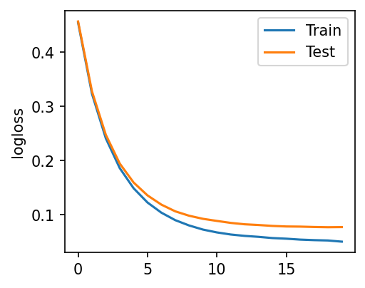

```python
#Here we can check learning cruves for our model using logloss
results_pre_opt = model.evals_result()
plt.figure(figsize=(3.5, 3), dpi=150)
# plot learning curves
plt.plot(results_pre_opt['validation_0']['logloss'], label='Train')
plt.plot(results_pre_opt['validation_1']['logloss'], label='Test')
plt.ylabel('logloss')
plt.legend()
```

Learning looks pretty decent with ~20 estimators

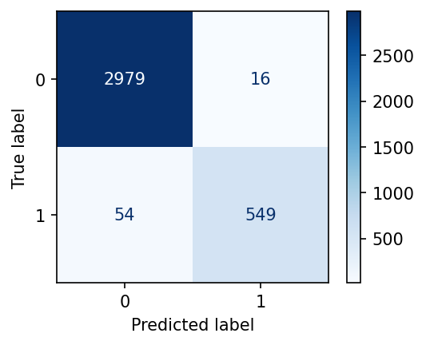

```python
plt.figure(figsize=(4,3), dpi=150)
# Compute values for confusion matrix
log_cm = confusion_matrix(y_test, y_pred)

# Create display of confusion matrix
log_disp = ConfusionMatrixDisplay(confusion_matrix=log_cm, display_labels=None)

try:
    log_disp.plot(cmap='Blues',ax=plt.gca())
except:
    pass
# Display plot
#plt.show()
```

```python
print(classification_report(y_test, y_pred))
```

```
              precision    recall  f1-score   support

           0       0.98      0.99      0.99      2995
           1       0.97      0.91      0.94       603

    accuracy                           0.98      3598
   macro avg       0.98      0.95      0.96      3598
weighted avg       0.98      0.98      0.98      3598
```

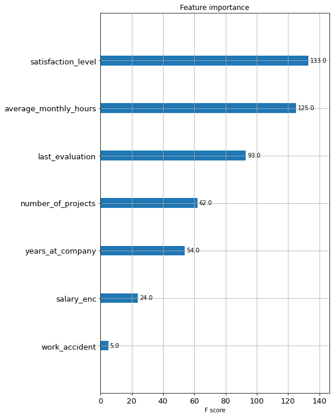

```python
fig, ax = plt.subplots(1,1,figsize=(8,10))
# plot feature importance
plot_importance(model, max_num_features=10,ax=ax, ylabel=None)
ax.tick_params(axis='both', which='major', labelsize=13)
ax.tick_params(axis='both', which='minor', labelsize=13)

plt.tight_layout()
#plt.savefig('feat_import_F.png', facecolor='white', transparent=False)
```

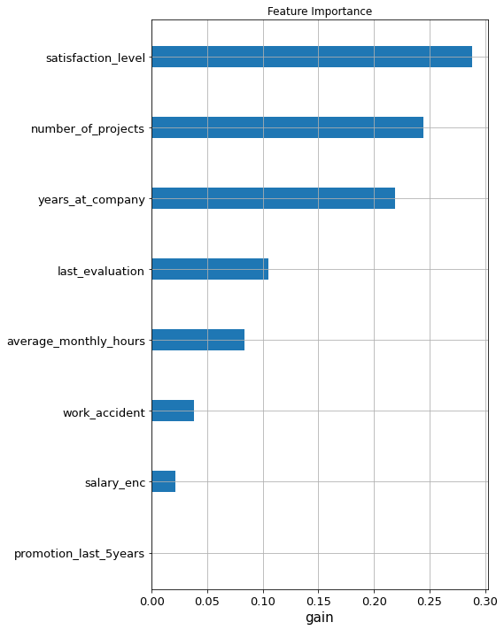

```python
# Get default feature_importance values (i.e. gain) and create a sorted dictionary
feature_names  = X_train.columns.tolist()
feat_imp_dict = dict(zip(feature_names, model.feature_importances_))
feat_imp_dict = {k: v for k, v in sorted(feat_imp_dict.items(), key=lambda item: item[1], reverse=True)}


#plot the feature importances
fig, ax = plt.subplots(1,1,figsize=(8,10))




#limt to top 15
limit = 10
ax.grid(zorder=0)
ax.barh(list(feat_imp_dict.keys())[:limit], list(feat_imp_dict.values())[:limit], height=0.3)
ax.invert_yaxis()
ax.set_xlabel('gain', fontsize=15)
#ax.set_ylabel('Features')
ax.tick_params(axis='both', which='major', labelsize=13)
ax.tick_params(axis='both', which='minor', labelsize=13)


plt.title('Feature Importance')
plt.tight_layout()
#plt.savefig('feat_import_gain.png', facecolor='white', transparent=False)
```

## Hyperparameter Tuning

Although our model works very well, we can try some parameter tuning to see if we can squeeze out a bit more performance. We will use the Hyperopt package for this task

```python
from hyperopt import hp, fmin, tpe, STATUS_OK, Trials

hyp_params = {

    'max_depth': hp.choice('max_depth', np.arange(5, 15, dtype=int)),
    'learning_rate': hp.loguniform('learning_rate', -5, -2),
    'subsample': hp.uniform('subsample', 0.25, 1),
    #'gamma': hp.uniform ('gamma', 0,2),
    'colsample_bytree' : hp.uniform('colsample_bytree', 0.5,1),
    'min_child_weight' : hp.quniform('min_child_weight', 0, 10, 1),
    'scale_pos_weight' : hp.uniform('scale_pos_weight', 1,2),
}
```

```python
n_estimators
```

```
20
```

```python
# An objective function is needed for the hyperopt tuning
def objective(hyp_params):
    clf=XGBClassifier(n_estimators=n_estimators,seed=seed,eval_metric='logloss', **hyp_params)

    evaluation = [( X_train, y_train), ( X_test, y_test)]

    clf.fit(X_train, y_train,
            eval_set=evaluation,  verbose=False)


    pred = clf.predict(X_test)
    accuracy_clf = f1_score(y_test, pred)
    print ("SCORE: {:.3f}".format( accuracy_clf))
    return {'loss': -accuracy_clf, 'status': STATUS_OK }
```

```python
trials = Trials()
best_params = fmin(objective, hyp_params, algo=tpe.suggest, max_evals=100, trials=trials)
print("Best set of hyperparameters: ", best_params)
```

```
SCORE: 0.919
SCORE: 0.924
SCORE: 0.937
SCORE: 0.935
SCORE: 0.928
SCORE: 0.932
SCORE: 0.936
SCORE: 0.921
SCORE: 0.935
SCORE: 0.925
SCORE: 0.931
SCORE: 0.931
SCORE: 0.939
SCORE: 0.926
SCORE: 0.927
SCORE: 0.933
SCORE: 0.927
SCORE: 0.925
SCORE: 0.929
SCORE: 0.920
SCORE: 0.939
SCORE: 0.940
SCORE: 0.943
SCORE: 0.943
SCORE: 0.949
SCORE: 0.947
SCORE: 0.943
SCORE: 0.933
SCORE: 0.948
SCORE: 0.942
SCORE: 0.943
SCORE: 0.948
SCORE: 0.937
SCORE: 0.940
SCORE: 0.941
SCORE: 0.932
SCORE: 0.941
SCORE: 0.934
SCORE: 0.942
SCORE: 0.936
```

[output cut: 46 more lines]

```
SCORE: 0.924
SCORE: 0.940
SCORE: 0.936
SCORE: 0.946
SCORE: 0.940
SCORE: 0.937
SCORE: 0.934
SCORE: 0.938
SCORE: 0.939
SCORE: 0.943
SCORE: 0.935
SCORE: 0.938
SCORE: 0.945
SCORE: 0.946
Best set of hyperparameters:  {'colsample_bytree': 0.6547164033139872, 'learning_rate': 0.11320931065700798, 'max_depth': 6, 'min_child_weight': 0.0, 'scale_pos_weight': 1.8823124437047563, 'subsample': 0.9342032119027921}
```

```python
#model_HT is the Hypertuned model

model_HT = XGBClassifier(n_estimators=n_estimators, seed=seed, eval_metric='logloss',  **best_params)


eval_set = [( X_train, y_train), ( X_test, y_test)]

model_HT.fit(X_train, y_train, eval_set=eval_set, verbose=False)


# make predictions for test data
y_pred = model_HT.predict(X_test)

# evaluate predictions
f1_HT = f1_score(y_test, y_pred)
print("Train-test-split F1: {:.2f}%".format(f1_HT * 100.0))
```

```
Train-test-split F1: 94.61%
```

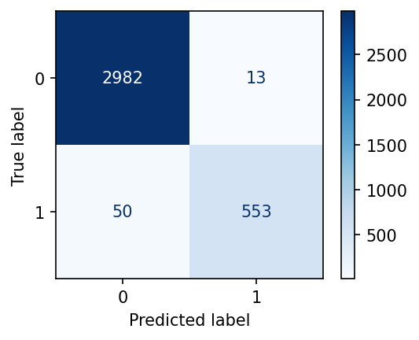

```python
plt.figure(figsize=(4,3), dpi=150)
# Compute values for confusion matrix
log_cm = confusion_matrix(y_test, y_pred)

# Create display of confusion matrix
log_disp = ConfusionMatrixDisplay(confusion_matrix=log_cm, display_labels=None)

try:
    log_disp.plot(cmap='Blues',ax=plt.gca())
except:
    pass
# Display plot
#plt.show()
```

```python
print(classification_report(y_test, y_pred))
```

```
              precision    recall  f1-score   support

           0       0.98      1.00      0.99      2995
           1       0.98      0.92      0.95       603

    accuracy                           0.98      3598
   macro avg       0.98      0.96      0.97      3598
weighted avg       0.98      0.98      0.98      3598
```

Hyperparameter tuning seems to provide slightly better results (I would probably consider this negligible, but it is an imporvement). We not have an F1 score of ~95%, and thus we will adopt the tuned parametrs for our base model.